# Farmer aging and succession

MtM ABM description

Author

David O’Sullivan

Published

February 19, 2025

Modified

May 5, 2026

## Farmer aging

Farmers age by five years per model tick (specified by hard-coded global `years-per-tick`).

After aging, a farmer is tested for exiting the industry (or retiring or dying, or however we want to think about it). They exit with a probability given by

$$p_{\mathrm{exit}} = \left\{
\begin{array}{cl}
\frac{5}{91-\mathrm{age}} & \text{if age} \lt 91 \\
1 & \text{if age} \geq 91
\end{array}
\right.
\tag{1}$$

## Age of farmers at model initialisation

The age of farmers at model initialisation is drawn from a [beta-binomial distribution](https://en.wikipedia.org/wiki/Beta-binomial_distribution), with $n=70$, $\alpha=5$, and $\beta=4$, and then offset by adding 20 (so that 20 is the youngest possible age). An example distribution for 1000 farmers is shown below, with the red line showing the associated probability density function.

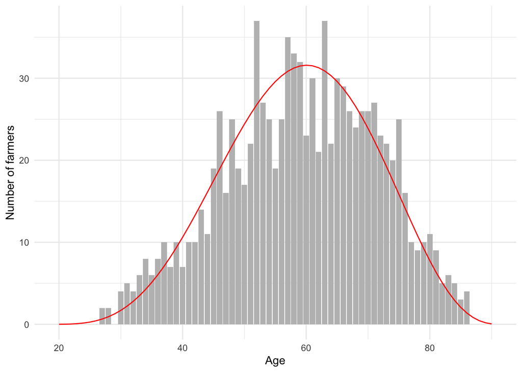

This distribution has been roughly matched to survey evidence of farmer ages (it has not been fitted, just matched approximately by eye).

## Age of new farmers

Incoming farmer ages are also drawn from a beta-binomial distribution with $n=45$, $\alpha=4$, $\alpha=2$ again offset so that the youngest farmers are 20.

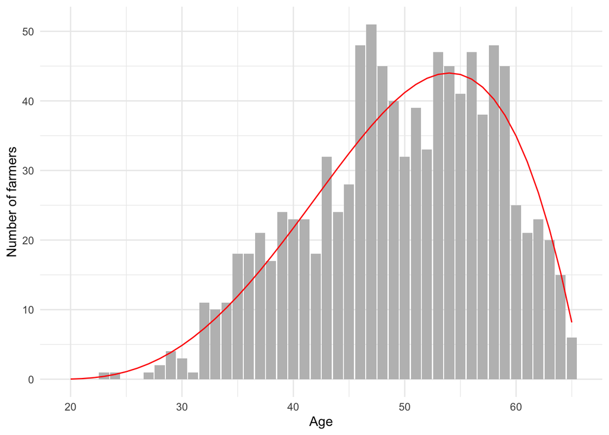

This distribution might appear to skew older than the model age initialisation, but note that the age range of the two distributions is different with the succession distribution topping out at 65 years as is clearer in the direct comparison of the probability density functions below.

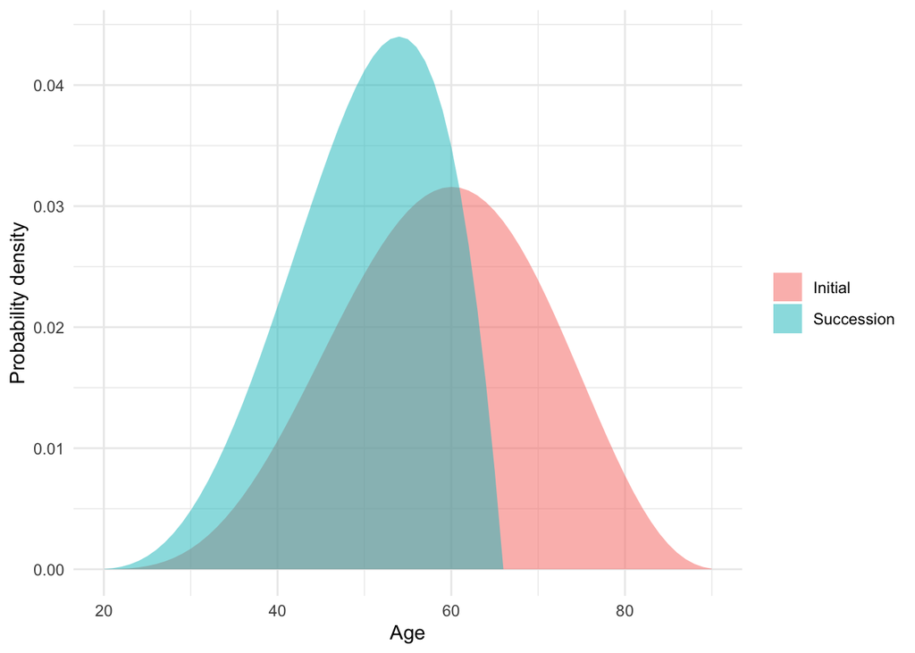

In any case, this parameterisation keeps the farmer age distribution stable over time.

More detailed fitting and analysis of these (hard-coded) parameter settings around farmer ages would be desirable if farmer age is considered a critical variable influencing outcomes.

## Entrant farmers and debt

With equal probability a new farmer inherits from the current farmer or is a new entrant to the market.

If the farm is inherited then the debt situation of the farmer is also inherited and the current loan, debt outstanding, etc. are unchanged.

If the farm is not inherited, then the new entrant must take on debt to purchase the farm for its estimated value (see Estimated value), and takes on a mortgage for between 20% and 80% of the estimated value of the farm. The 20-80% mortgage amount is evenly distributed, with any fraction of the farm’s value being equally likely.

**NoteUpdate History**

| Date | Changes |
| --- | --- |
| 2025-02-19 | Initial post. |
| 2025-10-17 | Updated to reflect changing in aging by 5 years per tick. |
| 2026-05-04 | Minor detail edits (n = 1000 in the histograms plots). |
| 2026-05-05 | Added new entrant farmers and debt |